# ProsperLoan-exploration

## Univariant Exploration

```python
import numpy as np
import pandas as pd
import matplotlib.pyplot as plt
import seaborn as sb
```

```python
df = pd.read_csv('prosperLoanData.csv')
```

```python
df.info()
df.head(10)
pd.set_option('display.max_columns', None)
```

```
<class 'pandas.core.frame.DataFrame'>
RangeIndex: 113937 entries, 0 to 113936
Data columns (total 81 columns):
 #   Column                               Non-Null Count   Dtype
---  ------                               --------------   -----
 0   ListingKey                           113937 non-null  object
 1   ListingNumber                        113937 non-null  int64
 2   ListingCreationDate                  113937 non-null  object
 3   CreditGrade                          28953 non-null   object
 4   Term                                 113937 non-null  int64
 5   LoanStatus                           113937 non-null  object
 6   ClosedDate                           55089 non-null   object
 7   BorrowerAPR                          113912 non-null  float64
 8   BorrowerRate                         113937 non-null  float64
 9   LenderYield                          113937 non-null  float64
```

[output cut: 73 more lines]

## Dataset Struture

The CreditGrade scale: NC, HR, E, D, C, B, A, AA The ProsperRating (Alpha) scale : N/A, HR, E, D, C, B, A, AA Both have simillar ratings

## Intrest behind exploring the dataset.

Determining the main factors involved in calclating the interest rate.

## First imprssions

According to the dataset dictionary, I strongly beleive that the columns CreditGrade and ProsperRating affect the interst rate directlty, ncomeRange and DebtToIncomeRatio are also a factor. Also the ProperScore and CreditScoreRange are correlated.

```python
# Making CreditGrade and ProsperScore ordinal.
ordinal_dict = {'CreditGrade': ['NC', 'HR', 'E', 'D', 'C', 'B', 'A', 'AA'],
                    'ProsperRating (Alpha)': ['N/A', 'HR', 'E', 'D', 'C', 'B', 'A', 'AA']}

for i in ordinal_dict:
    ordered_var = pd.api.types.CategoricalDtype(ordered=True, categories=ordinal_dict[i])
    df[i] = df[i].astype(ordered_var)
```

```python
df['CreditGrade'].value_counts()
```

```
C     5649
D     5153
B     4389
AA    3509
HR    3508
A     3315
E     3289
NC     141
Name: CreditGrade, dtype: int64
```

```python
df['ProsperRating (Alpha)'].value_counts()
```

```
C      18345
B      15581
A      14551
D      14274
E       9795
HR      6935
AA      5372
N/A        0
Name: ProsperRating (Alpha), dtype: int64
```

```python
df[['BorrowerAPR', 'BorrowerRate']].describe()
```

|  | BorrowerAPR | BorrowerRate |
| --- | --- | --- |
| count | 113912.000000 | 113937.000000 |
| mean | 0.218828 | 0.192764 |
| std | 0.080364 | 0.074818 |
| min | 0.006530 | 0.000000 |
| 25% | 0.156290 | 0.134000 |
| 50% | 0.209760 | 0.184000 |
| 75% | 0.283810 | 0.250000 |
| max | 0.512290 | 0.497500 |

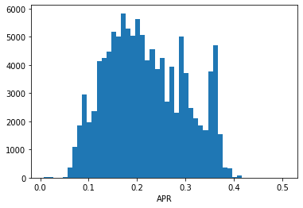

```python
#settting bins for histogram
binsAPR = np.arange(df.BorrowerAPR.min(), df.BorrowerAPR.max(), 0.01)
plt.hist(data=df, x='BorrowerAPR', bins=binsAPR);
plt.xlabel('APR');
```

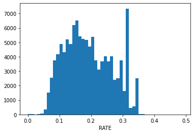

```python
binsRATE = np.arange(df.BorrowerRate.min(), df.BorrowerRate.max(), 0.01);
plt.hist(data=df, x='BorrowerRate', bins=binsRATE);
plt.xlabel('RATE');
```

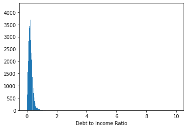

```python
binsRatio = np.arange(df.DebtToIncomeRatio.min(), df.DebtToIncomeRatio.max()+0.0, 0.01)
plt.hist(data=df, x='DebtToIncomeRatio', bins=binsRatio);
plt.xlabel('Debt to Income Ratio');
```

From the x-axis presented on the graph above it seems like there are some outliers that we need to deal with.

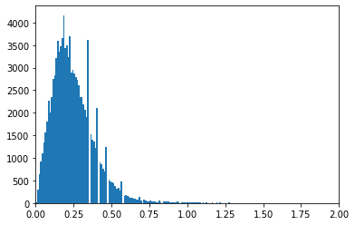

```python
#Plotting again but with a range from 0 to 2 on the x-axis
plt.hist(data=df, x='DebtToIncomeRatio', bins=binsRatio);
plt.xlim(0,2);
```

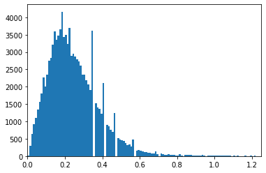

```python
#Plotting again but with a range from 0 to 1.25 on the x-axis
plt.hist(data=df, x='DebtToIncomeRatio', bins=binsRatio);
plt.xlim(0,1.25);
```

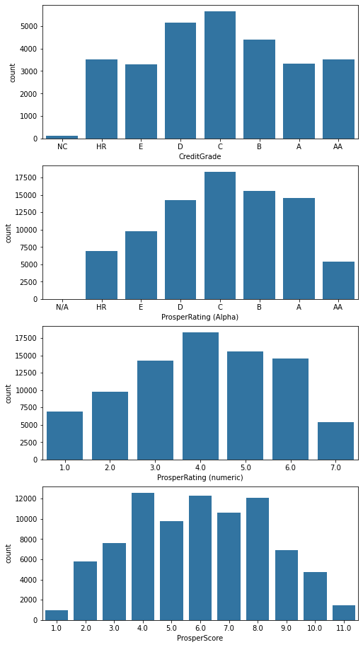

```python
#plotting ordnial values
fig, ax = plt.subplots(nrows=4, figsize = [8,16])

base_color = sb.color_palette()[0]

sb.countplot(data=df, x='CreditGrade', color=base_color, ax=ax[0]);
sb.countplot(data=df, x='ProsperRating (Alpha)', color=base_color, ax=ax[1]);
sb.countplot(data=df, x='ProsperRating (numeric)', color=base_color, ax=ax[2]);
sb.countplot(data=df, x='ProsperScore', color=base_color, ax=ax[3]);

plt.show()
```

ProsperScore distribution is slightly different from the other ratings, with high counts in the 4 and 8 scores, probably it depends on diffenrent or more data than the other ratings.

# Univariant Conclusion

## Bivariate Exploration

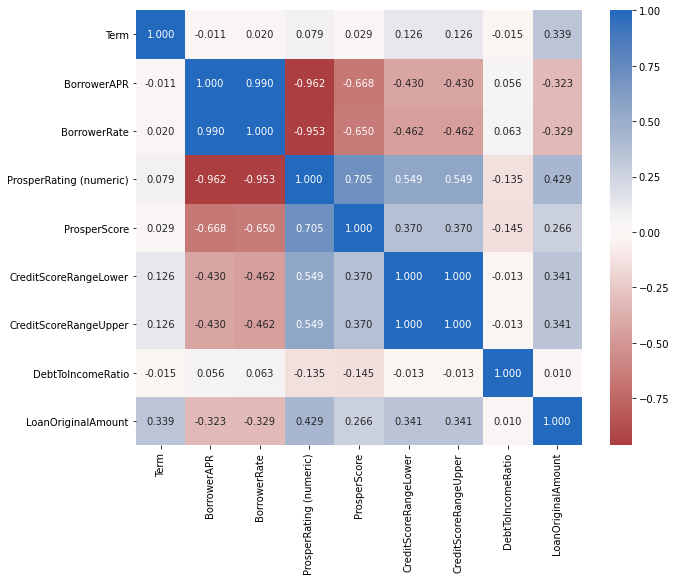

```python
#plot correlation of numeric values
numeric = ['Term',
                'BorrowerAPR',
                'BorrowerRate',
                'ProsperRating (numeric)',
                'ProsperScore',
                'CreditScoreRangeLower',
                'CreditScoreRangeUpper',
                'DebtToIncomeRatio',
                'LoanOriginalAmount']
plt.figure(figsize = [10, 8])
sb.heatmap(df[numeric].corr(), annot = True, fmt = '.3f',
           cmap = 'vlag_r', center = 0)

plt.show()
```

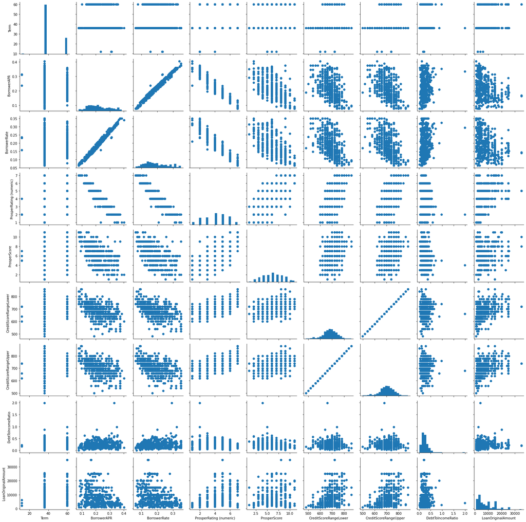

```python
# cjoosing a sample and plotting a pairgrid of all numeric variables
sample = np.random.choice(df.shape[0], 500, replace=False)
sample_ = df.loc[sample,:]


grid = sb.PairGrid(data=sample_, vars=numeric)
grid = grid.map_diag(plt.hist, bins=20);
grid.map_offdiag(plt.scatter);
```

Loans interest rate are highly correlated with ProsperRating (numeric). BorrowerRate and BorrowerAPR have the highest correlation with one another. Also, Showed by ProsperScore, a similar relationship between the interest rates and the ProsperRating, with some fluctuatuions. The most intresting part that there was no correlation spotted from DebtToIncomeRatio to the interest rate.

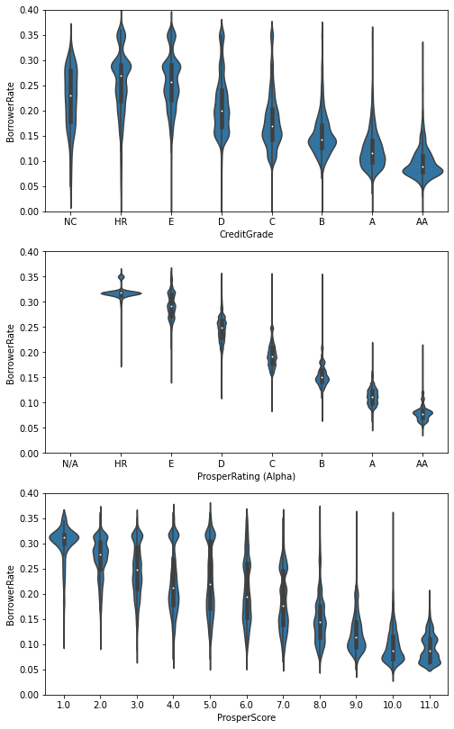

```python
#plotting violin graphs between (CreditGrade ,ProsperRating, ProsperScore) and BorrowerRate
plt.figure(figsize=[8,14])
plt.subplot(3,1,1)
sb.violinplot(data=df, x='CreditGrade', y='BorrowerRate', color=base_color);
plt.ylim((0,0.4));

plt.subplot(3,1,2)
sb.violinplot(data=df, x='ProsperRating (Alpha)', y='BorrowerRate', color=base_color);
plt.ylim((0,0.4));

plt.subplot(3,1,3)
sb.violinplot(data=df, x='ProsperScore', y='BorrowerRate', color=base_color);
plt.ylim((0,0.4));
```

Apparently, there's a negative correlation between having a higher score and a lower interest rate, which makes much sense. This is obvious in the results for the ProsperRating (Alpha) variable where the decline was sharp.ProsperScore has a decilne, but the distribution of the BorrowerRate is generally more normal, and the IQR is generally larger for each of the rating.

## Bivariate Discussion

Some of the credit risk score variables were related to the interest rate of the loans. This ws very obvious with the ProsperRating (Alpha). The results made much sense to real life scneanrios, where people with a better credit score will get a lower interest rate on their loans. As mentioned before, it was surprising how the DebtToIncomeRatio wasn't correlated to the interest rate.

## Multivariate Exploration

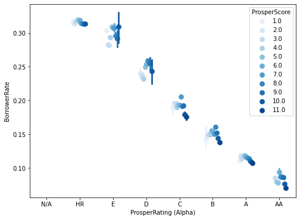

```python
fig = plt.figure(figsize=[8,6])

ax = sb.pointplot(data=df, x='ProsperRating (Alpha)', y='BorrowerRate', hue='ProsperScore',
                  dodge=0.4, linestyles='', palette='Blues');
```

This pointplot shows how the ProsperScore is distributed acorss the different credit risk scores in relation to BorrowerRate. It shows that ProsperScore might be using different criteria than the other credit risk scores, as suggested before.

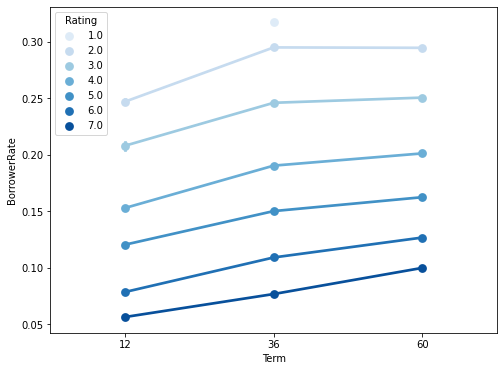

```python
fig = plt.figure(figsize=[8,6])

ax = sb.pointplot(data=df, x='Term', y='BorrowerRate', hue='ProsperRating (numeric)',
                   palette='Blues');
plt.legend(loc=2, title='Rating');
```

This pointplot shows how the BorrowerRate changes for different loan Terms, split up by ProsperRating.

## MultiVariate Discussions

Multivariate exploaration of the dataset explained why ProsperScore wasn't as highly correlated to the BorrowerRate. It uss different attributes to compute it's value. This was obvious after looking at the he ProsperScore and ProsperRating (Alpha) with relation to BorrowerRate.

Miltivariate exploration here showed something that wasn't clear in bivariate exploration; Inuitivley, one might think that shorter term loans should have higher interst as they introduce more risk. Howver the plot shows that the BorrowerRate increases as for longer Term loans.